# About the Data: The stocks we have chosen are from various industries and market caps namely

# Stock Market Analysis Using Python

About the Data: The stocks we have chosen are from various industries and market caps namely

• Apple • Google • Microsoft • Amazon

# For the start, we shall investigate the Amazon stock individually and then move on to the combined analysis

# Read the Data from Yahoo finance website directly

```python
import yfinance as yf
```

```python
Amazon_data= yf.Ticker("AMZN")
History_Amazon_data= Amazon_data.history('AMZN',start='2019-01-01',end='2023-01-01')
History_Amazon_data
```

| Date | Open | High | Low | Close | Volume | Dividends | Stock Splits |
| --- | --- | --- | --- | --- | --- | --- | --- |
| 2019-01-02 00:00:00-05:00 | 73.260002 | 77.667999 | 73.046501 | 76.956497 | 159662000 | 0.0 | 0.0 |
| 2019-01-03 00:00:00-05:00 | 76.000504 | 76.900002 | 74.855499 | 75.014000 | 139512000 | 0.0 | 0.0 |
| 2019-01-04 00:00:00-05:00 | 76.500000 | 79.699997 | 75.915497 | 78.769501 | 183652000 | 0.0 | 0.0 |
| 2019-01-07 00:00:00-05:00 | 80.115501 | 81.727997 | 79.459503 | 81.475502 | 159864000 | 0.0 | 0.0 |
| 2019-01-08 00:00:00-05:00 | 83.234497 | 83.830498 | 80.830498 | 82.829002 | 177628000 | 0.0 | 0.0 |
| ... | ... | ... | ... | ... | ... | ... | ... |
| 2022-12-23 00:00:00-05:00 | 83.250000 | 85.779999 | 82.930000 | 85.250000 | 57433700 | 0.0 | 0.0 |
| 2022-12-27 00:00:00-05:00 | 84.970001 | 85.349998 | 83.000000 | 83.040001 | 57284000 | 0.0 | 0.0 |
| 2022-12-28 00:00:00-05:00 | 82.800003 | 83.480003 | 81.690002 | 81.820000 | 58228600 | 0.0 | 0.0 |
| 2022-12-29 00:00:00-05:00 | 82.870003 | 84.550003 | 82.550003 | 84.180000 | 54995900 | 0.0 | 0.0 |
| 2022-12-30 00:00:00-05:00 | 83.120003 | 84.050003 | 82.470001 | 84.000000 | 62401200 | 0.0 | 0.0 |

1008 rows × 7 columns

```python
import pandas as pd
```

```python
Amazon_df=pd.DataFrame(History_Amazon_data)
```

```python
Amazon_df
```

| Date | Open | High | Low | Close | Volume | Dividends | Stock Splits |
| --- | --- | --- | --- | --- | --- | --- | --- |
| 2019-01-02 00:00:00-05:00 | 73.260002 | 77.667999 | 73.046501 | 76.956497 | 159662000 | 0.0 | 0.0 |
| 2019-01-03 00:00:00-05:00 | 76.000504 | 76.900002 | 74.855499 | 75.014000 | 139512000 | 0.0 | 0.0 |
| 2019-01-04 00:00:00-05:00 | 76.500000 | 79.699997 | 75.915497 | 78.769501 | 183652000 | 0.0 | 0.0 |
| 2019-01-07 00:00:00-05:00 | 80.115501 | 81.727997 | 79.459503 | 81.475502 | 159864000 | 0.0 | 0.0 |
| 2019-01-08 00:00:00-05:00 | 83.234497 | 83.830498 | 80.830498 | 82.829002 | 177628000 | 0.0 | 0.0 |
| ... | ... | ... | ... | ... | ... | ... | ... |
| 2022-12-23 00:00:00-05:00 | 83.250000 | 85.779999 | 82.930000 | 85.250000 | 57433700 | 0.0 | 0.0 |
| 2022-12-27 00:00:00-05:00 | 84.970001 | 85.349998 | 83.000000 | 83.040001 | 57284000 | 0.0 | 0.0 |
| 2022-12-28 00:00:00-05:00 | 82.800003 | 83.480003 | 81.690002 | 81.820000 | 58228600 | 0.0 | 0.0 |
| 2022-12-29 00:00:00-05:00 | 82.870003 | 84.550003 | 82.550003 | 84.180000 | 54995900 | 0.0 | 0.0 |
| 2022-12-30 00:00:00-05:00 | 83.120003 | 84.050003 | 82.470001 | 84.000000 | 62401200 | 0.0 | 0.0 |

1008 rows × 7 columns

# • Perform cleaning.

```python
Amazon_df.head(10)
```

| Date | Open | High | Low | Close | Volume | Dividends | Stock Splits |
| --- | --- | --- | --- | --- | --- | --- | --- |
| 2019-01-02 00:00:00-05:00 | 73.260002 | 77.667999 | 73.046501 | 76.956497 | 159662000 | 0.0 | 0.0 |
| 2019-01-03 00:00:00-05:00 | 76.000504 | 76.900002 | 74.855499 | 75.014000 | 139512000 | 0.0 | 0.0 |
| 2019-01-04 00:00:00-05:00 | 76.500000 | 79.699997 | 75.915497 | 78.769501 | 183652000 | 0.0 | 0.0 |
| 2019-01-07 00:00:00-05:00 | 80.115501 | 81.727997 | 79.459503 | 81.475502 | 159864000 | 0.0 | 0.0 |
| 2019-01-08 00:00:00-05:00 | 83.234497 | 83.830498 | 80.830498 | 82.829002 | 177628000 | 0.0 | 0.0 |
| 2019-01-09 00:00:00-05:00 | 82.649002 | 83.389999 | 82.070000 | 82.971001 | 126976000 | 0.0 | 0.0 |
| 2019-01-10 00:00:00-05:00 | 82.050499 | 83.162498 | 81.081001 | 82.810997 | 130154000 | 0.0 | 0.0 |
| 2019-01-11 00:00:00-05:00 | 82.027496 | 83.014503 | 81.810997 | 82.028000 | 93724000 | 0.0 | 0.0 |
| 2019-01-14 00:00:00-05:00 | 80.750000 | 82.410004 | 79.757500 | 80.860497 | 120118000 | 0.0 | 0.0 |
| 2019-01-15 00:00:00-05:00 | 81.599998 | 83.758003 | 81.300499 | 83.727997 | 119970000 | 0.0 | 0.0 |

```python
Amazon_df.tail(10)
```

| Date | Open | High | Low | Close | Volume | Dividends | Stock Splits |
| --- | --- | --- | --- | --- | --- | --- | --- |
| 2022-12-16 00:00:00-05:00 | 88.269997 | 89.349998 | 86.730003 | 87.860001 | 146144100 | 0.0 | 0.0 |
| 2022-12-19 00:00:00-05:00 | 87.510002 | 87.629997 | 84.510002 | 84.919998 | 83531500 | 0.0 | 0.0 |
| 2022-12-20 00:00:00-05:00 | 85.330002 | 86.610001 | 84.330002 | 85.190002 | 74348300 | 0.0 | 0.0 |
| 2022-12-21 00:00:00-05:00 | 86.180000 | 87.230003 | 85.209999 | 86.769997 | 59267200 | 0.0 | 0.0 |
| 2022-12-22 00:00:00-05:00 | 85.519997 | 85.680000 | 82.250000 | 83.790001 | 81431300 | 0.0 | 0.0 |
| 2022-12-23 00:00:00-05:00 | 83.250000 | 85.779999 | 82.930000 | 85.250000 | 57433700 | 0.0 | 0.0 |
| 2022-12-27 00:00:00-05:00 | 84.970001 | 85.349998 | 83.000000 | 83.040001 | 57284000 | 0.0 | 0.0 |
| 2022-12-28 00:00:00-05:00 | 82.800003 | 83.480003 | 81.690002 | 81.820000 | 58228600 | 0.0 | 0.0 |
| 2022-12-29 00:00:00-05:00 | 82.870003 | 84.550003 | 82.550003 | 84.180000 | 54995900 | 0.0 | 0.0 |
| 2022-12-30 00:00:00-05:00 | 83.120003 | 84.050003 | 82.470001 | 84.000000 | 62401200 | 0.0 | 0.0 |

```python
Amazon_df.info()
```

```
<class 'pandas.core.frame.DataFrame'>
DatetimeIndex: 1008 entries, 2019-01-02 00:00:00-05:00 to 2022-12-30 00:00:00-05:00
Data columns (total 7 columns):
 #   Column        Non-Null Count  Dtype
---  ------        --------------  -----
 0   Open          1008 non-null   float64
 1   High          1008 non-null   float64
 2   Low           1008 non-null   float64
 3   Close         1008 non-null   float64
 4   Volume        1008 non-null   int64
 5   Dividends     1008 non-null   float64
 6   Stock Splits  1008 non-null   float64
dtypes: float64(6), int64(1)
memory usage: 63.0 KB
```

```python
Amazon_df.describe()
```

|  | Open | High | Low | Close | Volume | Dividends | Stock Splits |
| --- | --- | --- | --- | --- | --- | --- | --- |
| count | 1008.000000 | 1008.000000 | 1008.000000 | 1008.000000 | 1.008000e+03 | 1008.0 | 1008.000000 |
| mean | 129.280653 | 130.842386 | 127.570479 | 129.206477 | 7.997662e+07 | 0.0 | 0.019841 |
| std | 33.485188 | 33.826750 | 33.054554 | 33.396156 | 3.468861e+07 | 0.0 | 0.629941 |
| min | 73.260002 | 76.900002 | 73.046501 | 75.014000 | 1.762600e+07 | 0.0 | 0.000000 |
| 25% | 93.903749 | 94.899002 | 92.920624 | 93.909374 | 5.647450e+07 | 0.0 | 0.000000 |
| 50% | 128.684998 | 130.675499 | 126.259998 | 127.859001 | 7.029100e+07 | 0.0 | 0.000000 |
| 75% | 161.136620 | 162.871254 | 159.203255 | 161.189873 | 9.386050e+07 | 0.0 | 0.000000 |
| max | 187.199997 | 188.654007 | 184.839493 | 186.570496 | 3.113460e+08 | 0.0 | 20.000000 |

```python
Amazon_df.dtypes
```

```
Open            float64
High            float64
Low             float64
Close           float64
Volume            int64
Dividends       float64
Stock Splits    float64
dtype: object
```

```python
Amazon_df.shape
```

```
(1008, 7)
```

```python
Amazon_df.size
```

```
7056
```

```python
Amazon_df.ndim
```

```
2
```

```python
Amazon_df.axes
```

```
[DatetimeIndex(['2019-01-02 00:00:00-05:00', '2019-01-03 00:00:00-05:00',
                '2019-01-04 00:00:00-05:00', '2019-01-07 00:00:00-05:00',
                '2019-01-08 00:00:00-05:00', '2019-01-09 00:00:00-05:00',
                '2019-01-10 00:00:00-05:00', '2019-01-11 00:00:00-05:00',
                '2019-01-14 00:00:00-05:00', '2019-01-15 00:00:00-05:00',
                ...
                '2022-12-16 00:00:00-05:00', '2022-12-19 00:00:00-05:00',
                '2022-12-20 00:00:00-05:00', '2022-12-21 00:00:00-05:00',
                '2022-12-22 00:00:00-05:00', '2022-12-23 00:00:00-05:00',
                '2022-12-27 00:00:00-05:00', '2022-12-28 00:00:00-05:00',
                '2022-12-29 00:00:00-05:00', '2022-12-30 00:00:00-05:00'],
               dtype='datetime64[ns, America/New_York]', name='Date', length=1008, freq=None),
 Index(['Open', 'High', 'Low', 'Close', 'Volume', 'Dividends', 'Stock Splits'], dtype='object')]
```

```python
Amazon_df.isnull()
```

| Date | Open | High | Low | Close | Volume | Dividends | Stock Splits |
| --- | --- | --- | --- | --- | --- | --- | --- |
| 2019-01-02 00:00:00-05:00 | False | False | False | False | False | False | False |
| 2019-01-03 00:00:00-05:00 | False | False | False | False | False | False | False |
| 2019-01-04 00:00:00-05:00 | False | False | False | False | False | False | False |
| 2019-01-07 00:00:00-05:00 | False | False | False | False | False | False | False |
| 2019-01-08 00:00:00-05:00 | False | False | False | False | False | False | False |
| ... | ... | ... | ... | ... | ... | ... | ... |
| 2022-12-23 00:00:00-05:00 | False | False | False | False | False | False | False |
| 2022-12-27 00:00:00-05:00 | False | False | False | False | False | False | False |
| 2022-12-28 00:00:00-05:00 | False | False | False | False | False | False | False |
| 2022-12-29 00:00:00-05:00 | False | False | False | False | False | False | False |
| 2022-12-30 00:00:00-05:00 | False | False | False | False | False | False | False |

1008 rows × 7 columns

```python
Amazon_df.isnull().sum()
```

```
Open            0
High            0
Low             0
Close           0
Volume          0
Dividends       0
Stock Splits    0
dtype: int64
```

```python
Amazon_df.columns
```

```
Index(['Open', 'High', 'Low', 'Close', 'Volume', 'Dividends', 'Stock Splits'], dtype='object')
```

```python
Amazon_df.duplicated()
```

```
Date
2019-01-02 00:00:00-05:00    False
2019-01-03 00:00:00-05:00    False
2019-01-04 00:00:00-05:00    False
2019-01-07 00:00:00-05:00    False
2019-01-08 00:00:00-05:00    False
                             ...
2022-12-23 00:00:00-05:00    False
2022-12-27 00:00:00-05:00    False
2022-12-28 00:00:00-05:00    False
2022-12-29 00:00:00-05:00    False
2022-12-30 00:00:00-05:00    False
Length: 1008, dtype: bool
```

```python
Amazon_df.duplicated().sum()
```

```
0
```

```python
Amazon_df[Amazon_df.duplicated()==True]
Amazon_df
```

| Date | Open | High | Low | Close | Volume | Dividends | Stock Splits |
| --- | --- | --- | --- | --- | --- | --- | --- |
| 2019-01-02 00:00:00-05:00 | 73.260002 | 77.667999 | 73.046501 | 76.956497 | 159662000 | 0.0 | 0.0 |
| 2019-01-03 00:00:00-05:00 | 76.000504 | 76.900002 | 74.855499 | 75.014000 | 139512000 | 0.0 | 0.0 |
| 2019-01-04 00:00:00-05:00 | 76.500000 | 79.699997 | 75.915497 | 78.769501 | 183652000 | 0.0 | 0.0 |
| 2019-01-07 00:00:00-05:00 | 80.115501 | 81.727997 | 79.459503 | 81.475502 | 159864000 | 0.0 | 0.0 |
| 2019-01-08 00:00:00-05:00 | 83.234497 | 83.830498 | 80.830498 | 82.829002 | 177628000 | 0.0 | 0.0 |
| ... | ... | ... | ... | ... | ... | ... | ... |
| 2022-12-23 00:00:00-05:00 | 83.250000 | 85.779999 | 82.930000 | 85.250000 | 57433700 | 0.0 | 0.0 |
| 2022-12-27 00:00:00-05:00 | 84.970001 | 85.349998 | 83.000000 | 83.040001 | 57284000 | 0.0 | 0.0 |
| 2022-12-28 00:00:00-05:00 | 82.800003 | 83.480003 | 81.690002 | 81.820000 | 58228600 | 0.0 | 0.0 |
| 2022-12-29 00:00:00-05:00 | 82.870003 | 84.550003 | 82.550003 | 84.180000 | 54995900 | 0.0 | 0.0 |
| 2022-12-30 00:00:00-05:00 | 83.120003 | 84.050003 | 82.470001 | 84.000000 | 62401200 | 0.0 | 0.0 |

1008 rows × 7 columns

```python
Amazon_df.drop("Dividends", axis=1, inplace=True)
Amazon_df
```

| Date | Open | High | Low | Close | Volume | Stock Splits |
| --- | --- | --- | --- | --- | --- | --- |
| 2019-01-02 00:00:00-05:00 | 73.260002 | 77.667999 | 73.046501 | 76.956497 | 159662000 | 0.0 |
| 2019-01-03 00:00:00-05:00 | 76.000504 | 76.900002 | 74.855499 | 75.014000 | 139512000 | 0.0 |
| 2019-01-04 00:00:00-05:00 | 76.500000 | 79.699997 | 75.915497 | 78.769501 | 183652000 | 0.0 |
| 2019-01-07 00:00:00-05:00 | 80.115501 | 81.727997 | 79.459503 | 81.475502 | 159864000 | 0.0 |
| 2019-01-08 00:00:00-05:00 | 83.234497 | 83.830498 | 80.830498 | 82.829002 | 177628000 | 0.0 |
| ... | ... | ... | ... | ... | ... | ... |
| 2022-12-23 00:00:00-05:00 | 83.250000 | 85.779999 | 82.930000 | 85.250000 | 57433700 | 0.0 |
| 2022-12-27 00:00:00-05:00 | 84.970001 | 85.349998 | 83.000000 | 83.040001 | 57284000 | 0.0 |
| 2022-12-28 00:00:00-05:00 | 82.800003 | 83.480003 | 81.690002 | 81.820000 | 58228600 | 0.0 |
| 2022-12-29 00:00:00-05:00 | 82.870003 | 84.550003 | 82.550003 | 84.180000 | 54995900 | 0.0 |
| 2022-12-30 00:00:00-05:00 | 83.120003 | 84.050003 | 82.470001 | 84.000000 | 62401200 | 0.0 |

1008 rows × 6 columns

```python
Amazon_df.drop("Stock Splits", axis=1, inplace=True)
Amazon_df
```

| Date | Open | High | Low | Close | Volume |
| --- | --- | --- | --- | --- | --- |
| 2019-01-02 00:00:00-05:00 | 73.260002 | 77.667999 | 73.046501 | 76.956497 | 159662000 |
| 2019-01-03 00:00:00-05:00 | 76.000504 | 76.900002 | 74.855499 | 75.014000 | 139512000 |
| 2019-01-04 00:00:00-05:00 | 76.500000 | 79.699997 | 75.915497 | 78.769501 | 183652000 |
| 2019-01-07 00:00:00-05:00 | 80.115501 | 81.727997 | 79.459503 | 81.475502 | 159864000 |
| 2019-01-08 00:00:00-05:00 | 83.234497 | 83.830498 | 80.830498 | 82.829002 | 177628000 |
| ... | ... | ... | ... | ... | ... |
| 2022-12-23 00:00:00-05:00 | 83.250000 | 85.779999 | 82.930000 | 85.250000 | 57433700 |
| 2022-12-27 00:00:00-05:00 | 84.970001 | 85.349998 | 83.000000 | 83.040001 | 57284000 |
| 2022-12-28 00:00:00-05:00 | 82.800003 | 83.480003 | 81.690002 | 81.820000 | 58228600 |
| 2022-12-29 00:00:00-05:00 | 82.870003 | 84.550003 | 82.550003 | 84.180000 | 54995900 |
| 2022-12-30 00:00:00-05:00 | 83.120003 | 84.050003 | 82.470001 | 84.000000 | 62401200 |

1008 rows × 5 columns

# • What was the change in stock price over time?

```python
Amazon_df['price change']=Amazon_df['Close'].diff()
Amazon_df
```

| Date | Open | High | Low | Close | Volume | price change |
| --- | --- | --- | --- | --- | --- | --- |
| 2019-01-02 00:00:00-05:00 | 73.260002 | 77.667999 | 73.046501 | 76.956497 | 159662000 | NaN |
| 2019-01-03 00:00:00-05:00 | 76.000504 | 76.900002 | 74.855499 | 75.014000 | 139512000 | -1.942497 |
| 2019-01-04 00:00:00-05:00 | 76.500000 | 79.699997 | 75.915497 | 78.769501 | 183652000 | 3.755501 |
| 2019-01-07 00:00:00-05:00 | 80.115501 | 81.727997 | 79.459503 | 81.475502 | 159864000 | 2.706001 |
| 2019-01-08 00:00:00-05:00 | 83.234497 | 83.830498 | 80.830498 | 82.829002 | 177628000 | 1.353500 |
| ... | ... | ... | ... | ... | ... | ... |
| 2022-12-23 00:00:00-05:00 | 83.250000 | 85.779999 | 82.930000 | 85.250000 | 57433700 | 1.459999 |
| 2022-12-27 00:00:00-05:00 | 84.970001 | 85.349998 | 83.000000 | 83.040001 | 57284000 | -2.209999 |
| 2022-12-28 00:00:00-05:00 | 82.800003 | 83.480003 | 81.690002 | 81.820000 | 58228600 | -1.220001 |
| 2022-12-29 00:00:00-05:00 | 82.870003 | 84.550003 | 82.550003 | 84.180000 | 54995900 | 2.360001 |
| 2022-12-30 00:00:00-05:00 | 83.120003 | 84.050003 | 82.470001 | 84.000000 | 62401200 | -0.180000 |

1008 rows × 6 columns

# • Visualize the change in a stock’s volume being traded, over time?

```python
import matplotlib.pyplot as plt
```

[figure not shown]

```python
plt.figure(figsize=(10, 6))
plt.plot(Amazon_df['Volume'], label='Amazon Close Price', color='m')
# Customize the plot
plt.title('Amazon Close Price Over Time')
plt.xlabel('Date')
plt.ylabel('Close Price')
plt.legend()
plt.grid(True)
# Show the plot
plt.show()
```

# • What was the moving average of various stocks?

```python
Amazon_df['50-Day MA']=Amazon_df['Close'].rolling(window=50).mean()
Amazon_df
```

| Date | Open | High | Low | Close | Volume | price change | 50-Day MA |
| --- | --- | --- | --- | --- | --- | --- | --- |
| 2019-01-02 00:00:00-05:00 | 73.260002 | 77.667999 | 73.046501 | 76.956497 | 159662000 | NaN | NaN |
| 2019-01-03 00:00:00-05:00 | 76.000504 | 76.900002 | 74.855499 | 75.014000 | 139512000 | -1.942497 | NaN |
| 2019-01-04 00:00:00-05:00 | 76.500000 | 79.699997 | 75.915497 | 78.769501 | 183652000 | 3.755501 | NaN |
| 2019-01-07 00:00:00-05:00 | 80.115501 | 81.727997 | 79.459503 | 81.475502 | 159864000 | 2.706001 | NaN |
| 2019-01-08 00:00:00-05:00 | 83.234497 | 83.830498 | 80.830498 | 82.829002 | 177628000 | 1.353500 | NaN |
| ... | ... | ... | ... | ... | ... | ... | ... |
| 2022-12-23 00:00:00-05:00 | 83.250000 | 85.779999 | 82.930000 | 85.250000 | 57433700 | 1.459999 | 96.9226 |
| 2022-12-27 00:00:00-05:00 | 84.970001 | 85.349998 | 83.000000 | 83.040001 | 57284000 | -2.209999 | 96.4454 |
| 2022-12-28 00:00:00-05:00 | 82.800003 | 83.480003 | 81.690002 | 81.820000 | 58228600 | -1.220001 | 95.8060 |
| 2022-12-29 00:00:00-05:00 | 82.870003 | 84.550003 | 82.550003 | 84.180000 | 54995900 | 2.360001 | 95.1624 |
| 2022-12-30 00:00:00-05:00 | 83.120003 | 84.050003 | 82.470001 | 84.000000 | 62401200 | -0.180000 | 94.5410 |

1008 rows × 7 columns

```python
Amazon_df['200-Day MA']=Amazon_df['Close'].rolling(window=200).mean()
Amazon_df
```

| Date | Open | High | Low | Close | Volume | price change | 50-Day MA | 200-Day MA |
| --- | --- | --- | --- | --- | --- | --- | --- | --- |
| 2019-01-02 00:00:00-05:00 | 73.260002 | 77.667999 | 73.046501 | 76.956497 | 159662000 | NaN | NaN | NaN |
| 2019-01-03 00:00:00-05:00 | 76.000504 | 76.900002 | 74.855499 | 75.014000 | 139512000 | -1.942497 | NaN | NaN |
| 2019-01-04 00:00:00-05:00 | 76.500000 | 79.699997 | 75.915497 | 78.769501 | 183652000 | 3.755501 | NaN | NaN |
| 2019-01-07 00:00:00-05:00 | 80.115501 | 81.727997 | 79.459503 | 81.475502 | 159864000 | 2.706001 | NaN | NaN |
| 2019-01-08 00:00:00-05:00 | 83.234497 | 83.830498 | 80.830498 | 82.829002 | 177628000 | 1.353500 | NaN | NaN |
| ... | ... | ... | ... | ... | ... | ... | ... | ... |
| 2022-12-23 00:00:00-05:00 | 83.250000 | 85.779999 | 82.930000 | 85.250000 | 57433700 | 1.459999 | 96.9226 | 120.649780 |
| 2022-12-27 00:00:00-05:00 | 84.970001 | 85.349998 | 83.000000 | 83.040001 | 57284000 | -2.209999 | 96.4454 | 120.337358 |
| 2022-12-28 00:00:00-05:00 | 82.800003 | 83.480003 | 81.690002 | 81.820000 | 58228600 | -1.220001 | 95.8060 | 120.037193 |
| 2022-12-29 00:00:00-05:00 | 82.870003 | 84.550003 | 82.550003 | 84.180000 | 54995900 | 2.360001 | 95.1624 | 119.721260 |
| 2022-12-30 00:00:00-05:00 | 83.120003 | 84.050003 | 82.470001 | 84.000000 | 62401200 | -0.180000 | 94.5410 | 119.375740 |

1008 rows × 8 columns

# • What was the daily return average of a stock?

```python
Amazon_df['Daily Return'] = Amazon_df['Close'].pct_change() * 100
```

```python
Amazon_df
```

| Date | Open | High | Low | Close | Volume | price change | 50-Day MA | 200-Day MA | Daily Return |
| --- | --- | --- | --- | --- | --- | --- | --- | --- | --- |
| 2019-01-02 00:00:00-05:00 | 73.260002 | 77.667999 | 73.046501 | 76.956497 | 159662000 | NaN | NaN | NaN | NaN |
| 2019-01-03 00:00:00-05:00 | 76.000504 | 76.900002 | 74.855499 | 75.014000 | 139512000 | -1.942497 | NaN | NaN | -2.524150 |
| 2019-01-04 00:00:00-05:00 | 76.500000 | 79.699997 | 75.915497 | 78.769501 | 183652000 | 3.755501 | NaN | NaN | 5.006400 |
| 2019-01-07 00:00:00-05:00 | 80.115501 | 81.727997 | 79.459503 | 81.475502 | 159864000 | 2.706001 | NaN | NaN | 3.435341 |
| 2019-01-08 00:00:00-05:00 | 83.234497 | 83.830498 | 80.830498 | 82.829002 | 177628000 | 1.353500 | NaN | NaN | 1.661236 |
| ... | ... | ... | ... | ... | ... | ... | ... | ... | ... |
| 2022-12-23 00:00:00-05:00 | 83.250000 | 85.779999 | 82.930000 | 85.250000 | 57433700 | 1.459999 | 96.9226 | 120.649780 | 1.742450 |
| 2022-12-27 00:00:00-05:00 | 84.970001 | 85.349998 | 83.000000 | 83.040001 | 57284000 | -2.209999 | 96.4454 | 120.337358 | -2.592374 |
| 2022-12-28 00:00:00-05:00 | 82.800003 | 83.480003 | 81.690002 | 81.820000 | 58228600 | -1.220001 | 95.8060 | 120.037193 | -1.469173 |
| 2022-12-29 00:00:00-05:00 | 82.870003 | 84.550003 | 82.550003 | 84.180000 | 54995900 | 2.360001 | 95.1624 | 119.721260 | 2.884381 |
| 2022-12-30 00:00:00-05:00 | 83.120003 | 84.050003 | 82.470001 | 84.000000 | 62401200 | -0.180000 | 94.5410 | 119.375740 | -0.213828 |

1008 rows × 9 columns

Calculate the average daily return

```python
Average_daily_return = Amazon_df['Daily Return'].mean()
Average_daily_return
```

```
0.034003000266935056
```

# • Add a new column ‘Trend’ whose values are based on the 'Daily Return'.

```python
Amazon_df['Trend'] = 'Stable'
Amazon_df.loc[Amazon_df['Daily Return'] > 0, 'Trend'] = 'Increase'
Amazon_df.loc[Amazon_df['Daily Return'] < 0, 'Trend'] = 'Decrease'
```

```python
Amazon_df
```

| Date | Open | High | Low | Close | Volume | price change | 50-Day MA | 200-Day MA | Daily Return | Trend |
| --- | --- | --- | --- | --- | --- | --- | --- | --- | --- | --- |
| 2019-01-02 00:00:00-05:00 | 73.260002 | 77.667999 | 73.046501 | 76.956497 | 159662000 | NaN | NaN | NaN | NaN | Stable |
| 2019-01-03 00:00:00-05:00 | 76.000504 | 76.900002 | 74.855499 | 75.014000 | 139512000 | -1.942497 | NaN | NaN | -2.524150 | Decrease |
| 2019-01-04 00:00:00-05:00 | 76.500000 | 79.699997 | 75.915497 | 78.769501 | 183652000 | 3.755501 | NaN | NaN | 5.006400 | Increase |
| 2019-01-07 00:00:00-05:00 | 80.115501 | 81.727997 | 79.459503 | 81.475502 | 159864000 | 2.706001 | NaN | NaN | 3.435341 | Increase |
| 2019-01-08 00:00:00-05:00 | 83.234497 | 83.830498 | 80.830498 | 82.829002 | 177628000 | 1.353500 | NaN | NaN | 1.661236 | Increase |
| ... | ... | ... | ... | ... | ... | ... | ... | ... | ... | ... |
| 2022-12-23 00:00:00-05:00 | 83.250000 | 85.779999 | 82.930000 | 85.250000 | 57433700 | 1.459999 | 96.9226 | 120.649780 | 1.742450 | Increase |
| 2022-12-27 00:00:00-05:00 | 84.970001 | 85.349998 | 83.000000 | 83.040001 | 57284000 | -2.209999 | 96.4454 | 120.337358 | -2.592374 | Decrease |
| 2022-12-28 00:00:00-05:00 | 82.800003 | 83.480003 | 81.690002 | 81.820000 | 58228600 | -1.220001 | 95.8060 | 120.037193 | -1.469173 | Decrease |
| 2022-12-29 00:00:00-05:00 | 82.870003 | 84.550003 | 82.550003 | 84.180000 | 54995900 | 2.360001 | 95.1624 | 119.721260 | 2.884381 | Increase |
| 2022-12-30 00:00:00-05:00 | 83.120003 | 84.050003 | 82.470001 | 84.000000 | 62401200 | -0.180000 | 94.5410 | 119.375740 | -0.213828 | Decrease |

1008 rows × 10 columns

# • Visualize trend frequency through a Pie Chart.

Count the frequency of each trend

```python
trend_counts = Amazon_df['Trend'].value_counts()
trend_counts
```

```
Increase    521
Decrease    486
Stable        1
Name: Trend, dtype: int64
```

Plotting a Pie Chart

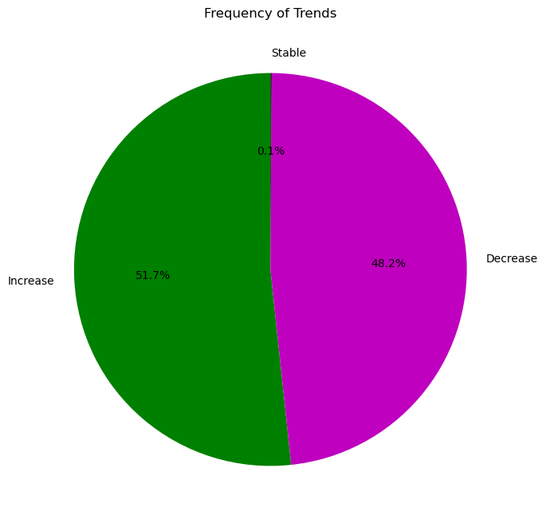

```python
plt.figure(figsize=(8, 8))
plt.pie(trend_counts, labels=trend_counts.index, autopct='%1.1f%%', startangle=90, colors=['g', 'm', 'k'])
# Adding title
plt.title('Frequency of Trends')

# show the plot
plt.show()
```

# End of investigate the Amazon stock individually and now we are move on to the combined analysis.

Apple, Google, Microsoft, Amazon

# Read the Data from Yahoo finance website directly.

```python
import pandas as pd
import yfinance as yf
stock_symbols = ['AAPL', 'GOOGL', 'MSFT', 'AMZN']
combined_stock_data = yf.download(stock_symbols, start='2019-01-01', end='2023-01-01',)
```

```
[*********************100%%**********************]  4 of 4 completed
```

```python
combined_stock_data
```

| Date | Adj Close AAPL | Adj Close AMZN | Adj Close GOOGL | Adj Close MSFT | Close AAPL | Close AMZN | Close GOOGL | Close MSFT | High AAPL | High AMZN | ... | Low GOOGL | Low MSFT | Open AAPL | Open AMZN | Open GOOGL | Open MSFT | Volume AAPL | Volume AMZN | Volume GOOGL | Volume MSFT |
| --- | --- | --- | --- | --- | --- | --- | --- | --- | --- | --- | --- | --- | --- | --- | --- | --- | --- | --- | --- | --- | --- |
| 2019-01-02 | 37.893337 | 76.956497 | 52.734001 | 96.023262 | 39.480000 | 76.956497 | 52.734001 | 101.120003 | 39.712502 | 77.667999 | ... | 51.264000 | 98.940002 | 38.722500 | 73.260002 | 51.360001 | 99.550003 | 148158800 | 159662000 | 31868000 | 35329300 |
| 2019-01-03 | 34.118881 | 75.014000 | 51.273499 | 92.490768 | 35.547501 | 75.014000 | 51.273499 | 97.400002 | 36.430000 | 76.900002 | ... | 51.118500 | 97.199997 | 35.994999 | 76.000504 | 52.533501 | 100.099998 | 365248800 | 139512000 | 41960000 | 42579100 |
| 2019-01-04 | 35.575382 | 78.769501 | 53.903500 | 96.792442 | 37.064999 | 78.769501 | 53.903500 | 101.930000 | 37.137501 | 79.699997 | ... | 51.842999 | 98.930000 | 36.132500 | 76.500000 | 52.127998 | 99.720001 | 234428400 | 183652000 | 46022000 | 44060600 |
| 2019-01-07 | 35.496193 | 81.475502 | 53.796001 | 96.915886 | 36.982498 | 81.475502 | 53.796001 | 102.059998 | 37.207500 | 81.727997 | ... | 53.132000 | 100.980003 | 37.174999 | 80.115501 | 54.048500 | 101.639999 | 219111200 | 159864000 | 47446000 | 35656100 |
| 2019-01-08 | 36.172871 | 82.829002 | 54.268501 | 97.618607 | 37.687500 | 82.829002 | 54.268501 | 102.800003 | 37.955002 | 83.830498 | ... | 53.417500 | 101.709999 | 37.389999 | 83.234497 | 54.299999 | 103.040001 | 164101200 | 177628000 | 35414000 | 31514400 |
| ... | ... | ... | ... | ... | ... | ... | ... | ... | ... | ... | ... | ... | ... | ... | ... | ... | ... | ... | ... | ... | ... |
| 2022-12-23 | 131.127060 | 85.250000 | 89.230003 | 236.631805 | 131.860001 | 85.250000 | 89.230003 | 238.729996 | 132.419998 | 85.779999 | ... | 87.070000 | 233.940002 | 130.919998 | 83.250000 | 87.110001 | 236.110001 | 63814900 | 57433700 | 23003000 | 21207000 |
| 2022-12-27 | 129.307251 | 83.040001 | 87.389999 | 234.877380 | 130.029999 | 83.040001 | 87.389999 | 236.960007 | 131.410004 | 85.349998 | ... | 87.010002 | 235.830002 | 131.380005 | 84.970001 | 88.800003 | 238.699997 | 69007800 | 57284000 | 20097300 | 16688600 |
| 2022-12-28 | 125.339409 | 81.820000 | 86.019997 | 232.468719 | 126.040001 | 81.820000 | 86.019997 | 234.529999 | 131.029999 | 83.480003 | ... | 85.940002 | 234.169998 | 129.669998 | 82.800003 | 86.980003 | 236.889999 | 85438400 | 58228600 | 19523200 | 17457100 |
| 2022-12-29 | 128.889572 | 84.180000 | 88.449997 | 238.891769 | 129.610001 | 84.180000 | 88.449997 | 241.009995 | 130.479996 | 84.550003 | ... | 86.610001 | 235.649994 | 127.989998 | 82.870003 | 86.620003 | 235.649994 | 75703700 | 54995900 | 23333500 | 19770700 |
| 2022-12-30 | 129.207779 | 84.000000 | 88.230003 | 237.712219 | 129.929993 | 84.000000 | 88.230003 | 239.820007 | 129.949997 | 84.050003 | ... | 86.570000 | 236.660004 | 128.410004 | 83.120003 | 86.980003 | 238.210007 | 77034200 | 62401200 | 23986300 | 21938500 |

1008 rows × 24 columns

# Perform cleaning.

```python
combined_stock_data.head(10)
```

| Date | Adj Close AAPL | Adj Close AMZN | Adj Close GOOGL | Adj Close MSFT | Close AAPL | Close AMZN | Close GOOGL | Close MSFT | High AAPL | High AMZN | ... | Low GOOGL | Low MSFT | Open AAPL | Open AMZN | Open GOOGL | Open MSFT | Volume AAPL | Volume AMZN | Volume GOOGL | Volume MSFT |
| --- | --- | --- | --- | --- | --- | --- | --- | --- | --- | --- | --- | --- | --- | --- | --- | --- | --- | --- | --- | --- | --- |
| 2019-01-02 | 37.893337 | 76.956497 | 52.734001 | 96.023262 | 39.480000 | 76.956497 | 52.734001 | 101.120003 | 39.712502 | 77.667999 | ... | 51.264000 | 98.940002 | 38.722500 | 73.260002 | 51.360001 | 99.550003 | 148158800 | 159662000 | 31868000 | 35329300 |
| 2019-01-03 | 34.118881 | 75.014000 | 51.273499 | 92.490768 | 35.547501 | 75.014000 | 51.273499 | 97.400002 | 36.430000 | 76.900002 | ... | 51.118500 | 97.199997 | 35.994999 | 76.000504 | 52.533501 | 100.099998 | 365248800 | 139512000 | 41960000 | 42579100 |
| 2019-01-04 | 35.575382 | 78.769501 | 53.903500 | 96.792442 | 37.064999 | 78.769501 | 53.903500 | 101.930000 | 37.137501 | 79.699997 | ... | 51.842999 | 98.930000 | 36.132500 | 76.500000 | 52.127998 | 99.720001 | 234428400 | 183652000 | 46022000 | 44060600 |
| 2019-01-07 | 35.496193 | 81.475502 | 53.796001 | 96.915886 | 36.982498 | 81.475502 | 53.796001 | 102.059998 | 37.207500 | 81.727997 | ... | 53.132000 | 100.980003 | 37.174999 | 80.115501 | 54.048500 | 101.639999 | 219111200 | 159864000 | 47446000 | 35656100 |
| 2019-01-08 | 36.172871 | 82.829002 | 54.268501 | 97.618607 | 37.687500 | 82.829002 | 54.268501 | 102.800003 | 37.955002 | 83.830498 | ... | 53.417500 | 101.709999 | 37.389999 | 83.234497 | 54.299999 | 103.040001 | 164101200 | 177628000 | 35414000 | 31514400 |
| 2019-01-09 | 36.787148 | 82.971001 | 54.082500 | 99.014481 | 38.327499 | 82.971001 | 54.082500 | 104.269997 | 38.632500 | 83.389999 | ... | 53.718498 | 103.239998 | 37.822498 | 82.649002 | 54.399502 | 103.860001 | 180396400 | 126976000 | 26998000 | 32280800 |
| 2019-01-10 | 36.904732 | 82.810997 | 53.941502 | 98.378250 | 38.450001 | 82.810997 | 53.941502 | 103.599998 | 38.492500 | 83.162498 | ... | 53.234001 | 102.379997 | 38.125000 | 82.050499 | 53.747002 | 103.220001 | 143122800 | 130154000 | 26598000 | 30067600 |
| 2019-01-11 | 36.542397 | 82.028000 | 53.223499 | 97.618607 | 38.072498 | 82.028000 | 53.223499 | 102.800003 | 38.424999 | 83.014503 | ... | 52.821499 | 101.639999 | 38.220001 | 82.027496 | 53.494999 | 103.190002 | 108092800 | 93724000 | 30864000 | 28314200 |
| 2019-01-14 | 35.992908 | 80.860497 | 52.575500 | 96.906380 | 37.500000 | 80.860497 | 52.575500 | 102.050003 | 37.817501 | 82.410004 | ... | 52.427502 | 101.260002 | 37.712502 | 80.750000 | 52.667000 | 101.900002 | 129756800 | 120118000 | 28490000 | 28437100 |
| 2019-01-15 | 36.729572 | 83.727997 | 54.325500 | 99.717216 | 38.267502 | 83.727997 | 54.325500 | 105.010002 | 38.347500 | 83.758003 | ... | 52.722000 | 101.879997 | 37.567501 | 81.599998 | 52.900501 | 102.510002 | 114843600 | 119970000 | 37518000 | 31587600 |

10 rows × 24 columns

```python
combined_stock_data.tail(10)
```

| Date | Adj Close AAPL | Adj Close AMZN | Adj Close GOOGL | Adj Close MSFT | Close AAPL | Close AMZN | Close GOOGL | Close MSFT | High AAPL | High AMZN | ... | Low GOOGL | Low MSFT | Open AAPL | Open AMZN | Open GOOGL | Open MSFT | Volume AAPL | Volume AMZN | Volume GOOGL | Volume MSFT |
| --- | --- | --- | --- | --- | --- | --- | --- | --- | --- | --- | --- | --- | --- | --- | --- | --- | --- | --- | --- | --- | --- |
| 2022-12-16 | 133.762329 | 87.860001 | 90.260002 | 242.539429 | 134.509995 | 87.860001 | 90.260002 | 244.690002 | 137.649994 | 89.349998 | ... | 89.519997 | 243.509995 | 136.690002 | 88.269997 | 90.760002 | 248.550003 | 160156900 | 146144100 | 58011800 | 86102000 |
| 2022-12-19 | 131.634216 | 84.919998 | 88.440002 | 238.336700 | 132.369995 | 84.919998 | 88.440002 | 240.449997 | 135.199997 | 87.629997 | ... | 88.209999 | 238.710007 | 135.110001 | 87.510002 | 90.260002 | 244.860001 | 79592600 | 83531500 | 29493000 | 29696400 |
| 2022-12-20 | 131.564621 | 85.190002 | 89.019997 | 239.674820 | 132.300003 | 85.190002 | 89.019997 | 241.800003 | 133.250000 | 86.610001 | ... | 87.440002 | 238.419998 | 131.389999 | 85.330002 | 88.110001 | 239.399994 | 77432800 | 74348300 | 23453800 | 25150800 |
| 2022-12-21 | 134.697128 | 86.769997 | 89.580002 | 242.281708 | 135.449997 | 86.769997 | 89.580002 | 244.429993 | 136.809998 | 87.230003 | ... | 88.320000 | 240.110001 | 132.979996 | 86.180000 | 89.080002 | 241.690002 | 85928000 | 59267200 | 24745600 | 23690600 |
| 2022-12-22 | 131.494995 | 83.790001 | 87.760002 | 236.096558 | 132.229996 | 83.790001 | 87.760002 | 238.190002 | 134.559998 | 85.680000 | ... | 86.320000 | 233.869995 | 134.350006 | 85.519997 | 88.160004 | 241.259995 | 77852100 | 81431300 | 27658300 | 28651700 |
| 2022-12-23 | 131.127060 | 85.250000 | 89.230003 | 236.631805 | 131.860001 | 85.250000 | 89.230003 | 238.729996 | 132.419998 | 85.779999 | ... | 87.070000 | 233.940002 | 130.919998 | 83.250000 | 87.110001 | 236.110001 | 63814900 | 57433700 | 23003000 | 21207000 |
| 2022-12-27 | 129.307251 | 83.040001 | 87.389999 | 234.877380 | 130.029999 | 83.040001 | 87.389999 | 236.960007 | 131.410004 | 85.349998 | ... | 87.010002 | 235.830002 | 131.380005 | 84.970001 | 88.800003 | 238.699997 | 69007800 | 57284000 | 20097300 | 16688600 |
| 2022-12-28 | 125.339409 | 81.820000 | 86.019997 | 232.468719 | 126.040001 | 81.820000 | 86.019997 | 234.529999 | 131.029999 | 83.480003 | ... | 85.940002 | 234.169998 | 129.669998 | 82.800003 | 86.980003 | 236.889999 | 85438400 | 58228600 | 19523200 | 17457100 |
| 2022-12-29 | 128.889572 | 84.180000 | 88.449997 | 238.891769 | 129.610001 | 84.180000 | 88.449997 | 241.009995 | 130.479996 | 84.550003 | ... | 86.610001 | 235.649994 | 127.989998 | 82.870003 | 86.620003 | 235.649994 | 75703700 | 54995900 | 23333500 | 19770700 |
| 2022-12-30 | 129.207779 | 84.000000 | 88.230003 | 237.712219 | 129.929993 | 84.000000 | 88.230003 | 239.820007 | 129.949997 | 84.050003 | ... | 86.570000 | 236.660004 | 128.410004 | 83.120003 | 86.980003 | 238.210007 | 77034200 | 62401200 | 23986300 | 21938500 |

10 rows × 24 columns

```python
combined_stock_data.info()
```

```
<class 'pandas.core.frame.DataFrame'>
DatetimeIndex: 1008 entries, 2019-01-02 to 2022-12-30
Data columns (total 24 columns):
 #   Column              Non-Null Count  Dtype
---  ------              --------------  -----
 0   (Adj Close, AAPL)   1008 non-null   float64
 1   (Adj Close, AMZN)   1008 non-null   float64
 2   (Adj Close, GOOGL)  1008 non-null   float64
 3   (Adj Close, MSFT)   1008 non-null   float64
 4   (Close, AAPL)       1008 non-null   float64
 5   (Close, AMZN)       1008 non-null   float64
 6   (Close, GOOGL)      1008 non-null   float64
 7   (Close, MSFT)       1008 non-null   float64
 8   (High, AAPL)        1008 non-null   float64
 9   (High, AMZN)        1008 non-null   float64
```

[output cut: 16 more lines]

```python
combined_stock_data.describe()
```

|  | Adj Close AAPL | Adj Close AMZN | Adj Close GOOGL | Adj Close MSFT | Close AAPL | Close AMZN | Close GOOGL | Close MSFT | High AAPL | High AMZN | ... | Low GOOGL | Low MSFT | Open AAPL | Open AMZN | Open GOOGL | Open MSFT | Volume AAPL | Volume AMZN | Volume GOOGL | Volume MSFT |
| --- | --- | --- | --- | --- | --- | --- | --- | --- | --- | --- | --- | --- | --- | --- | --- | --- | --- | --- | --- | --- | --- |
| count | 1008.000000 | 1008.000000 | 1008.000000 | 1008.000000 | 1008.000000 | 1008.000000 | 1008.000000 | 1008.000000 | 1008.000000 | 1008.000000 | ... | 1008.000000 | 1008.000000 | 1008.000000 | 1008.000000 | 1008.000000 | 1008.000000 | 1.008000e+03 | 1.008000e+03 | 1.008000e+03 | 1.008000e+03 |
| mean | 109.030964 | 129.206477 | 93.083453 | 211.691679 | 110.749856 | 129.206477 | 93.083453 | 216.991210 | 112.034063 | 130.842386 | ... | 92.029637 | 214.528174 | 110.665816 | 129.280653 | 93.063726 | 216.929930 | 1.120997e+08 | 7.997662e+07 | 3.387898e+07 | 2.987462e+07 |
| std | 43.227054 | 33.396156 | 30.072634 | 65.410579 | 43.223091 | 33.396156 | 30.072634 | 65.235722 | 43.771753 | 33.826750 | ... | 29.765786 | 64.511300 | 43.242655 | 33.485188 | 30.136264 | 65.281546 | 5.310973e+07 | 3.468861e+07 | 1.538946e+07 | 1.272080e+07 |
| min | 34.118881 | 75.014000 | 51.273499 | 92.490768 | 35.547501 | 75.014000 | 51.273499 | 97.400002 | 36.430000 | 76.900002 | ... | 50.443501 | 97.199997 | 35.994999 | 73.260002 | 51.360001 | 99.550003 | 3.519590e+07 | 1.762600e+07 | 9.312000e+06 | 8.989200e+06 |
| 25% | 65.003309 | 93.909374 | 64.723625 | 148.253025 | 66.695627 | 93.909374 | 64.723625 | 153.532505 | 67.390625 | 94.899002 | ... | 63.977373 | 150.992504 | 66.600000 | 93.903749 | 64.546124 | 152.040005 | 7.755390e+07 | 5.647450e+07 | 2.412450e+07 | 2.189630e+07 |
| 50% | 121.693165 | 127.859001 | 88.104000 | 216.533798 | 123.645000 | 127.859001 | 88.104000 | 221.539993 | 125.080002 | 130.675499 | ... | 87.076752 | 219.130005 | 123.705002 | 128.684998 | 88.178253 | 222.014999 | 9.693830e+07 | 7.029100e+07 | 3.010100e+07 | 2.681040e+07 |
| 75% | 145.690025 | 161.189873 | 117.501625 | 263.673141 | 147.044994 | 161.189873 | 117.501625 | 267.670006 | 148.767502 | 162.871254 | ... | 116.008625 | 264.662506 | 147.014996 | 161.136620 | 117.167500 | 266.200005 | 1.290616e+08 | 9.386050e+07 | 3.829900e+07 | 3.389500e+07 |
| max | 179.953888 | 186.570496 | 149.838501 | 336.937256 | 182.009995 | 186.570496 | 149.838501 | 343.109985 | 182.940002 | 188.654007 | ... | 148.899002 | 342.200012 | 182.630005 | 187.199997 | 151.250000 | 344.619995 | 4.265100e+08 | 3.113460e+08 | 1.331780e+08 | 9.701270e+07 |

8 rows × 24 columns

```python
combined_stock_data.shape
```

```
(1008, 24)
```

```python
combined_stock_data.size
```

```
24192
```

```python
combined_stock_data.axes
```

```
[DatetimeIndex(['2019-01-02', '2019-01-03', '2019-01-04', '2019-01-07',
                '2019-01-08', '2019-01-09', '2019-01-10', '2019-01-11',
                '2019-01-14', '2019-01-15',
                ...
                '2022-12-16', '2022-12-19', '2022-12-20', '2022-12-21',
                '2022-12-22', '2022-12-23', '2022-12-27', '2022-12-28',
                '2022-12-29', '2022-12-30'],
               dtype='datetime64[ns]', name='Date', length=1008, freq=None),
 MultiIndex([('Adj Close',  'AAPL'),
             ('Adj Close',  'AMZN'),
             ('Adj Close', 'GOOGL'),
             ('Adj Close',  'MSFT'),
             (    'Close',  'AAPL'),
             (    'Close',  'AMZN'),
             (    'Close', 'GOOGL'),
             (    'Close',  'MSFT'),
             (     'High',  'AAPL'),
             (     'High',  'AMZN'),
             (     'High', 'GOOGL'),
             (     'High',  'MSFT'),
             (      'Low',  'AAPL'),
             (      'Low',  'AMZN'),
             (      'Low', 'GOOGL'),
             (      'Low',  'MSFT'),
             (     'Open',  'AAPL'),
             (     'Open',  'AMZN'),
             (     'Open', 'GOOGL'),
             (     'Open',  'MSFT'),
             (   'Volume',  'AAPL'),
             (   'Volume',  'AMZN'),
             (   'Volume', 'GOOGL'),
             (   'Volume',  'MSFT')],
            )]
```

```python
combined_stock_data.ndim
```

```
2
```

```python
combined_stock_data.columns
```

```
MultiIndex([('Adj Close',  'AAPL'),
            ('Adj Close',  'AMZN'),
            ('Adj Close', 'GOOGL'),
            ('Adj Close',  'MSFT'),
            (    'Close',  'AAPL'),
            (    'Close',  'AMZN'),
            (    'Close', 'GOOGL'),
            (    'Close',  'MSFT'),
            (     'High',  'AAPL'),
            (     'High',  'AMZN'),
            (     'High', 'GOOGL'),
            (     'High',  'MSFT'),
            (      'Low',  'AAPL'),
            (      'Low',  'AMZN'),
            (      'Low', 'GOOGL'),
            (      'Low',  'MSFT'),
            (     'Open',  'AAPL'),
            (     'Open',  'AMZN'),
            (     'Open', 'GOOGL'),
            (     'Open',  'MSFT'),
            (   'Volume',  'AAPL'),
            (   'Volume',  'AMZN'),
            (   'Volume', 'GOOGL'),
            (   'Volume',  'MSFT')],
           )
```

```python
combined_stock_data.dtypes
```

```
Adj Close  AAPL     float64
           AMZN     float64
           GOOGL    float64
           MSFT     float64
Close      AAPL     float64
           AMZN     float64
           GOOGL    float64
           MSFT     float64
High       AAPL     float64
           AMZN     float64
           GOOGL    float64
           MSFT     float64
Low        AAPL     float64
           AMZN     float64
           GOOGL    float64
           MSFT     float64
Open       AAPL     float64
           AMZN     float64
           GOOGL    float64
           MSFT     float64
Volume     AAPL       int64
           AMZN       int64
           GOOGL      int64
           MSFT       int64
dtype: object
```

```python
combined_stock_data.duplicated()
```

```
Date
2019-01-02    False
2019-01-03    False
2019-01-04    False
2019-01-07    False
2019-01-08    False
              ...
2022-12-23    False
2022-12-27    False
2022-12-28    False
2022-12-29    False
2022-12-30    False
Length: 1008, dtype: bool
```

```python
combined_stock_data.duplicated().sum()
```

```
0
```

```python
combined_stock_data.isnull()
```

| Date | Adj Close AAPL | Adj Close AMZN | Adj Close GOOGL | Adj Close MSFT | Close AAPL | Close AMZN | Close GOOGL | Close MSFT | High AAPL | High AMZN | ... | Low GOOGL | Low MSFT | Open AAPL | Open AMZN | Open GOOGL | Open MSFT | Volume AAPL | Volume AMZN | Volume GOOGL | Volume MSFT |
| --- | --- | --- | --- | --- | --- | --- | --- | --- | --- | --- | --- | --- | --- | --- | --- | --- | --- | --- | --- | --- | --- |
| 2019-01-02 | False | False | False | False | False | False | False | False | False | False | ... | False | False | False | False | False | False | False | False | False | False |
| 2019-01-03 | False | False | False | False | False | False | False | False | False | False | ... | False | False | False | False | False | False | False | False | False | False |
| 2019-01-04 | False | False | False | False | False | False | False | False | False | False | ... | False | False | False | False | False | False | False | False | False | False |
| 2019-01-07 | False | False | False | False | False | False | False | False | False | False | ... | False | False | False | False | False | False | False | False | False | False |
| 2019-01-08 | False | False | False | False | False | False | False | False | False | False | ... | False | False | False | False | False | False | False | False | False | False |
| ... | ... | ... | ... | ... | ... | ... | ... | ... | ... | ... | ... | ... | ... | ... | ... | ... | ... | ... | ... | ... | ... |
| 2022-12-23 | False | False | False | False | False | False | False | False | False | False | ... | False | False | False | False | False | False | False | False | False | False |
| 2022-12-27 | False | False | False | False | False | False | False | False | False | False | ... | False | False | False | False | False | False | False | False | False | False |
| 2022-12-28 | False | False | False | False | False | False | False | False | False | False | ... | False | False | False | False | False | False | False | False | False | False |
| 2022-12-29 | False | False | False | False | False | False | False | False | False | False | ... | False | False | False | False | False | False | False | False | False | False |
| 2022-12-30 | False | False | False | False | False | False | False | False | False | False | ... | False | False | False | False | False | False | False | False | False | False |

1008 rows × 24 columns

```python
combined_stock_data.isnull().sum()
```

```
Adj Close  AAPL     0
           AMZN     0
           GOOGL    0
           MSFT     0
Close      AAPL     0
           AMZN     0
           GOOGL    0
           MSFT     0
High       AAPL     0
           AMZN     0
           GOOGL    0
           MSFT     0
Low        AAPL     0
           AMZN     0
           GOOGL    0
           MSFT     0
Open       AAPL     0
           AMZN     0
           GOOGL    0
           MSFT     0
Volume     AAPL     0
           AMZN     0
           GOOGL    0
           MSFT     0
dtype: int64
```

# What was the change in stock price over time?

```python
combined_stock_data['Concatenated_Column'] =combined_stock_data['Close',  'AAPL'].astype(int)  +combined_stock_data['Close',  'AMZN'].astype(int)  +combined_stock_data['Close', 'GOOGL'].astype(int)  + combined_stock_data['Close',  'MSFT'].astype(int)
```

```python
combined_stock_data["Over time"] =combined_stock_data["Concatenated_Column"].diff()
```

```python
combined_stock_data
```

| Date | Adj Close AAPL | Adj Close AMZN | Adj Close GOOGL | Adj Close MSFT | Close AAPL | Close AMZN | Close GOOGL | Close MSFT | High AAPL | High AMZN | ... | Open AAPL | Open AMZN | Open GOOGL | Open MSFT | Volume AAPL | Volume AMZN | Volume GOOGL | Volume MSFT | Concatenated_Column | Over time |
| --- | --- | --- | --- | --- | --- | --- | --- | --- | --- | --- | --- | --- | --- | --- | --- | --- | --- | --- | --- | --- | --- |
| 2019-01-02 | 37.893337 | 76.956497 | 52.734001 | 96.023262 | 39.480000 | 76.956497 | 52.734001 | 101.120003 | 39.712502 | 77.667999 | ... | 38.722500 | 73.260002 | 51.360001 | 99.550003 | 148158800 | 159662000 | 31868000 | 35329300 | 268 | NaN |
| 2019-01-03 | 34.118881 | 75.014000 | 51.273499 | 92.490768 | 35.547501 | 75.014000 | 51.273499 | 97.400002 | 36.430000 | 76.900002 | ... | 35.994999 | 76.000504 | 52.533501 | 100.099998 | 365248800 | 139512000 | 41960000 | 42579100 | 258 | -10.0 |
| 2019-01-04 | 35.575382 | 78.769501 | 53.903500 | 96.792442 | 37.064999 | 78.769501 | 53.903500 | 101.930000 | 37.137501 | 79.699997 | ... | 36.132500 | 76.500000 | 52.127998 | 99.720001 | 234428400 | 183652000 | 46022000 | 44060600 | 269 | 11.0 |
| 2019-01-07 | 35.496193 | 81.475502 | 53.796001 | 96.915886 | 36.982498 | 81.475502 | 53.796001 | 102.059998 | 37.207500 | 81.727997 | ... | 37.174999 | 80.115501 | 54.048500 | 101.639999 | 219111200 | 159864000 | 47446000 | 35656100 | 272 | 3.0 |
| 2019-01-08 | 36.172871 | 82.829002 | 54.268501 | 97.618607 | 37.687500 | 82.829002 | 54.268501 | 102.800003 | 37.955002 | 83.830498 | ... | 37.389999 | 83.234497 | 54.299999 | 103.040001 | 164101200 | 177628000 | 35414000 | 31514400 | 275 | 3.0 |
| ... | ... | ... | ... | ... | ... | ... | ... | ... | ... | ... | ... | ... | ... | ... | ... | ... | ... | ... | ... | ... | ... |
| 2022-12-23 | 131.127060 | 85.250000 | 89.230003 | 236.631805 | 131.860001 | 85.250000 | 89.230003 | 238.729996 | 132.419998 | 85.779999 | ... | 130.919998 | 83.250000 | 87.110001 | 236.110001 | 63814900 | 57433700 | 23003000 | 21207000 | 543 | 3.0 |
| 2022-12-27 | 129.307251 | 83.040001 | 87.389999 | 234.877380 | 130.029999 | 83.040001 | 87.389999 | 236.960007 | 131.410004 | 85.349998 | ... | 131.380005 | 84.970001 | 88.800003 | 238.699997 | 69007800 | 57284000 | 20097300 | 16688600 | 536 | -7.0 |
| 2022-12-28 | 125.339409 | 81.820000 | 86.019997 | 232.468719 | 126.040001 | 81.820000 | 86.019997 | 234.529999 | 131.029999 | 83.480003 | ... | 129.669998 | 82.800003 | 86.980003 | 236.889999 | 85438400 | 58228600 | 19523200 | 17457100 | 527 | -9.0 |
| 2022-12-29 | 128.889572 | 84.180000 | 88.449997 | 238.891769 | 129.610001 | 84.180000 | 88.449997 | 241.009995 | 130.479996 | 84.550003 | ... | 127.989998 | 82.870003 | 86.620003 | 235.649994 | 75703700 | 54995900 | 23333500 | 19770700 | 542 | 15.0 |
| 2022-12-30 | 129.207779 | 84.000000 | 88.230003 | 237.712219 | 129.929993 | 84.000000 | 88.230003 | 239.820007 | 129.949997 | 84.050003 | ... | 128.410004 | 83.120003 | 86.980003 | 238.210007 | 77034200 | 62401200 | 23986300 | 21938500 | 540 | -2.0 |

1008 rows × 26 columns

Replace NaN values with 0 in-place

```python
combined_stock_data.fillna(0, inplace=True)
```

```python
combined_stock_data
```

| Date | Adj Close AAPL | Adj Close AMZN | Adj Close GOOGL | Adj Close MSFT | Close AAPL | Close AMZN | Close GOOGL | Close MSFT | High AAPL | High AMZN | ... | Open AAPL | Open AMZN | Open GOOGL | Open MSFT | Volume AAPL | Volume AMZN | Volume GOOGL | Volume MSFT | Concatenated_Column | Over time |
| --- | --- | --- | --- | --- | --- | --- | --- | --- | --- | --- | --- | --- | --- | --- | --- | --- | --- | --- | --- | --- | --- |
| 2019-01-02 | 37.893337 | 76.956497 | 52.734001 | 96.023262 | 39.480000 | 76.956497 | 52.734001 | 101.120003 | 39.712502 | 77.667999 | ... | 38.722500 | 73.260002 | 51.360001 | 99.550003 | 148158800 | 159662000 | 31868000 | 35329300 | 268 | 0.0 |
| 2019-01-03 | 34.118881 | 75.014000 | 51.273499 | 92.490768 | 35.547501 | 75.014000 | 51.273499 | 97.400002 | 36.430000 | 76.900002 | ... | 35.994999 | 76.000504 | 52.533501 | 100.099998 | 365248800 | 139512000 | 41960000 | 42579100 | 258 | -10.0 |
| 2019-01-04 | 35.575382 | 78.769501 | 53.903500 | 96.792442 | 37.064999 | 78.769501 | 53.903500 | 101.930000 | 37.137501 | 79.699997 | ... | 36.132500 | 76.500000 | 52.127998 | 99.720001 | 234428400 | 183652000 | 46022000 | 44060600 | 269 | 11.0 |
| 2019-01-07 | 35.496193 | 81.475502 | 53.796001 | 96.915886 | 36.982498 | 81.475502 | 53.796001 | 102.059998 | 37.207500 | 81.727997 | ... | 37.174999 | 80.115501 | 54.048500 | 101.639999 | 219111200 | 159864000 | 47446000 | 35656100 | 272 | 3.0 |
| 2019-01-08 | 36.172871 | 82.829002 | 54.268501 | 97.618607 | 37.687500 | 82.829002 | 54.268501 | 102.800003 | 37.955002 | 83.830498 | ... | 37.389999 | 83.234497 | 54.299999 | 103.040001 | 164101200 | 177628000 | 35414000 | 31514400 | 275 | 3.0 |
| ... | ... | ... | ... | ... | ... | ... | ... | ... | ... | ... | ... | ... | ... | ... | ... | ... | ... | ... | ... | ... | ... |
| 2022-12-23 | 131.127060 | 85.250000 | 89.230003 | 236.631805 | 131.860001 | 85.250000 | 89.230003 | 238.729996 | 132.419998 | 85.779999 | ... | 130.919998 | 83.250000 | 87.110001 | 236.110001 | 63814900 | 57433700 | 23003000 | 21207000 | 543 | 3.0 |
| 2022-12-27 | 129.307251 | 83.040001 | 87.389999 | 234.877380 | 130.029999 | 83.040001 | 87.389999 | 236.960007 | 131.410004 | 85.349998 | ... | 131.380005 | 84.970001 | 88.800003 | 238.699997 | 69007800 | 57284000 | 20097300 | 16688600 | 536 | -7.0 |
| 2022-12-28 | 125.339409 | 81.820000 | 86.019997 | 232.468719 | 126.040001 | 81.820000 | 86.019997 | 234.529999 | 131.029999 | 83.480003 | ... | 129.669998 | 82.800003 | 86.980003 | 236.889999 | 85438400 | 58228600 | 19523200 | 17457100 | 527 | -9.0 |
| 2022-12-29 | 128.889572 | 84.180000 | 88.449997 | 238.891769 | 129.610001 | 84.180000 | 88.449997 | 241.009995 | 130.479996 | 84.550003 | ... | 127.989998 | 82.870003 | 86.620003 | 235.649994 | 75703700 | 54995900 | 23333500 | 19770700 | 542 | 15.0 |
| 2022-12-30 | 129.207779 | 84.000000 | 88.230003 | 237.712219 | 129.929993 | 84.000000 | 88.230003 | 239.820007 | 129.949997 | 84.050003 | ... | 128.410004 | 83.120003 | 86.980003 | 238.210007 | 77034200 | 62401200 | 23986300 | 21938500 | 540 | -2.0 |

1008 rows × 26 columns

Now we are create a "Over Time" Column:

```python
combined_stock_data["Over_time"] =combined_stock_data["Concatenated_Column"].diff()
```

```python
combined_stock_data
```

| Date | Adj Close AAPL | Adj Close AMZN | Adj Close GOOGL | Adj Close MSFT | Close AAPL | Close AMZN | Close GOOGL | Close MSFT | High AAPL | High AMZN | ... | Open AMZN | Open GOOGL | Open MSFT | Volume AAPL | Volume AMZN | Volume GOOGL | Volume MSFT | Concatenated_Column | Over time | Over_time |
| --- | --- | --- | --- | --- | --- | --- | --- | --- | --- | --- | --- | --- | --- | --- | --- | --- | --- | --- | --- | --- | --- |
| 2019-01-02 | 37.893337 | 76.956497 | 52.734001 | 96.023262 | 39.480000 | 76.956497 | 52.734001 | 101.120003 | 39.712502 | 77.667999 | ... | 73.260002 | 51.360001 | 99.550003 | 148158800 | 159662000 | 31868000 | 35329300 | 268 | 0.0 | NaN |
| 2019-01-03 | 34.118881 | 75.014000 | 51.273499 | 92.490768 | 35.547501 | 75.014000 | 51.273499 | 97.400002 | 36.430000 | 76.900002 | ... | 76.000504 | 52.533501 | 100.099998 | 365248800 | 139512000 | 41960000 | 42579100 | 258 | -10.0 | -10.0 |
| 2019-01-04 | 35.575382 | 78.769501 | 53.903500 | 96.792442 | 37.064999 | 78.769501 | 53.903500 | 101.930000 | 37.137501 | 79.699997 | ... | 76.500000 | 52.127998 | 99.720001 | 234428400 | 183652000 | 46022000 | 44060600 | 269 | 11.0 | 11.0 |
| 2019-01-07 | 35.496193 | 81.475502 | 53.796001 | 96.915886 | 36.982498 | 81.475502 | 53.796001 | 102.059998 | 37.207500 | 81.727997 | ... | 80.115501 | 54.048500 | 101.639999 | 219111200 | 159864000 | 47446000 | 35656100 | 272 | 3.0 | 3.0 |
| 2019-01-08 | 36.172871 | 82.829002 | 54.268501 | 97.618607 | 37.687500 | 82.829002 | 54.268501 | 102.800003 | 37.955002 | 83.830498 | ... | 83.234497 | 54.299999 | 103.040001 | 164101200 | 177628000 | 35414000 | 31514400 | 275 | 3.0 | 3.0 |
| ... | ... | ... | ... | ... | ... | ... | ... | ... | ... | ... | ... | ... | ... | ... | ... | ... | ... | ... | ... | ... | ... |
| 2022-12-23 | 131.127060 | 85.250000 | 89.230003 | 236.631805 | 131.860001 | 85.250000 | 89.230003 | 238.729996 | 132.419998 | 85.779999 | ... | 83.250000 | 87.110001 | 236.110001 | 63814900 | 57433700 | 23003000 | 21207000 | 543 | 3.0 | 3.0 |
| 2022-12-27 | 129.307251 | 83.040001 | 87.389999 | 234.877380 | 130.029999 | 83.040001 | 87.389999 | 236.960007 | 131.410004 | 85.349998 | ... | 84.970001 | 88.800003 | 238.699997 | 69007800 | 57284000 | 20097300 | 16688600 | 536 | -7.0 | -7.0 |
| 2022-12-28 | 125.339409 | 81.820000 | 86.019997 | 232.468719 | 126.040001 | 81.820000 | 86.019997 | 234.529999 | 131.029999 | 83.480003 | ... | 82.800003 | 86.980003 | 236.889999 | 85438400 | 58228600 | 19523200 | 17457100 | 527 | -9.0 | -9.0 |
| 2022-12-29 | 128.889572 | 84.180000 | 88.449997 | 238.891769 | 129.610001 | 84.180000 | 88.449997 | 241.009995 | 130.479996 | 84.550003 | ... | 82.870003 | 86.620003 | 235.649994 | 75703700 | 54995900 | 23333500 | 19770700 | 542 | 15.0 | 15.0 |
| 2022-12-30 | 129.207779 | 84.000000 | 88.230003 | 237.712219 | 129.929993 | 84.000000 | 88.230003 | 239.820007 | 129.949997 | 84.050003 | ... | 83.120003 | 86.980003 | 238.210007 | 77034200 | 62401200 | 23986300 | 21938500 | 540 | -2.0 | -2.0 |

1008 rows × 27 columns

# Visualize the change in a stock’s volume being traded, over time?

```python
combined_stock_data
```

| Date | Adj Close AAPL | Adj Close AMZN | Adj Close GOOGL | Adj Close MSFT | Close AAPL | Close AMZN | Close GOOGL | Close MSFT | High AAPL | High AMZN | ... | Open AMZN | Open GOOGL | Open MSFT | Volume AAPL | Volume AMZN | Volume GOOGL | Volume MSFT | Concatenated_Column | Over time | Over_time |
| --- | --- | --- | --- | --- | --- | --- | --- | --- | --- | --- | --- | --- | --- | --- | --- | --- | --- | --- | --- | --- | --- |
| 2019-01-02 | 37.893337 | 76.956497 | 52.734001 | 96.023262 | 39.480000 | 76.956497 | 52.734001 | 101.120003 | 39.712502 | 77.667999 | ... | 73.260002 | 51.360001 | 99.550003 | 148158800 | 159662000 | 31868000 | 35329300 | 268 | 0.0 | NaN |
| 2019-01-03 | 34.118881 | 75.014000 | 51.273499 | 92.490768 | 35.547501 | 75.014000 | 51.273499 | 97.400002 | 36.430000 | 76.900002 | ... | 76.000504 | 52.533501 | 100.099998 | 365248800 | 139512000 | 41960000 | 42579100 | 258 | -10.0 | -10.0 |
| 2019-01-04 | 35.575382 | 78.769501 | 53.903500 | 96.792442 | 37.064999 | 78.769501 | 53.903500 | 101.930000 | 37.137501 | 79.699997 | ... | 76.500000 | 52.127998 | 99.720001 | 234428400 | 183652000 | 46022000 | 44060600 | 269 | 11.0 | 11.0 |
| 2019-01-07 | 35.496193 | 81.475502 | 53.796001 | 96.915886 | 36.982498 | 81.475502 | 53.796001 | 102.059998 | 37.207500 | 81.727997 | ... | 80.115501 | 54.048500 | 101.639999 | 219111200 | 159864000 | 47446000 | 35656100 | 272 | 3.0 | 3.0 |
| 2019-01-08 | 36.172871 | 82.829002 | 54.268501 | 97.618607 | 37.687500 | 82.829002 | 54.268501 | 102.800003 | 37.955002 | 83.830498 | ... | 83.234497 | 54.299999 | 103.040001 | 164101200 | 177628000 | 35414000 | 31514400 | 275 | 3.0 | 3.0 |
| ... | ... | ... | ... | ... | ... | ... | ... | ... | ... | ... | ... | ... | ... | ... | ... | ... | ... | ... | ... | ... | ... |
| 2022-12-23 | 131.127060 | 85.250000 | 89.230003 | 236.631805 | 131.860001 | 85.250000 | 89.230003 | 238.729996 | 132.419998 | 85.779999 | ... | 83.250000 | 87.110001 | 236.110001 | 63814900 | 57433700 | 23003000 | 21207000 | 543 | 3.0 | 3.0 |
| 2022-12-27 | 129.307251 | 83.040001 | 87.389999 | 234.877380 | 130.029999 | 83.040001 | 87.389999 | 236.960007 | 131.410004 | 85.349998 | ... | 84.970001 | 88.800003 | 238.699997 | 69007800 | 57284000 | 20097300 | 16688600 | 536 | -7.0 | -7.0 |
| 2022-12-28 | 125.339409 | 81.820000 | 86.019997 | 232.468719 | 126.040001 | 81.820000 | 86.019997 | 234.529999 | 131.029999 | 83.480003 | ... | 82.800003 | 86.980003 | 236.889999 | 85438400 | 58228600 | 19523200 | 17457100 | 527 | -9.0 | -9.0 |
| 2022-12-29 | 128.889572 | 84.180000 | 88.449997 | 238.891769 | 129.610001 | 84.180000 | 88.449997 | 241.009995 | 130.479996 | 84.550003 | ... | 82.870003 | 86.620003 | 235.649994 | 75703700 | 54995900 | 23333500 | 19770700 | 542 | 15.0 | 15.0 |
| 2022-12-30 | 129.207779 | 84.000000 | 88.230003 | 237.712219 | 129.929993 | 84.000000 | 88.230003 | 239.820007 | 129.949997 | 84.050003 | ... | 83.120003 | 86.980003 | 238.210007 | 77034200 | 62401200 | 23986300 | 21938500 | 540 | -2.0 | -2.0 |

1008 rows × 27 columns

```python
combined_stock_data.isnull()
```

| Date | Adj Close AAPL | Adj Close AMZN | Adj Close GOOGL | Adj Close MSFT | Close AAPL | Close AMZN | Close GOOGL | Close MSFT | High AAPL | High AMZN | ... | Open AMZN | Open GOOGL | Open MSFT | Volume AAPL | Volume AMZN | Volume GOOGL | Volume MSFT | Concatenated_Column | Over time | Over_time |
| --- | --- | --- | --- | --- | --- | --- | --- | --- | --- | --- | --- | --- | --- | --- | --- | --- | --- | --- | --- | --- | --- |
| 2019-01-02 | False | False | False | False | False | False | False | False | False | False | ... | False | False | False | False | False | False | False | False | False | True |
| 2019-01-03 | False | False | False | False | False | False | False | False | False | False | ... | False | False | False | False | False | False | False | False | False | False |
| 2019-01-04 | False | False | False | False | False | False | False | False | False | False | ... | False | False | False | False | False | False | False | False | False | False |
| 2019-01-07 | False | False | False | False | False | False | False | False | False | False | ... | False | False | False | False | False | False | False | False | False | False |
| 2019-01-08 | False | False | False | False | False | False | False | False | False | False | ... | False | False | False | False | False | False | False | False | False | False |
| ... | ... | ... | ... | ... | ... | ... | ... | ... | ... | ... | ... | ... | ... | ... | ... | ... | ... | ... | ... | ... | ... |
| 2022-12-23 | False | False | False | False | False | False | False | False | False | False | ... | False | False | False | False | False | False | False | False | False | False |
| 2022-12-27 | False | False | False | False | False | False | False | False | False | False | ... | False | False | False | False | False | False | False | False | False | False |
| 2022-12-28 | False | False | False | False | False | False | False | False | False | False | ... | False | False | False | False | False | False | False | False | False | False |
| 2022-12-29 | False | False | False | False | False | False | False | False | False | False | ... | False | False | False | False | False | False | False | False | False | False |
| 2022-12-30 | False | False | False | False | False | False | False | False | False | False | ... | False | False | False | False | False | False | False | False | False | False |

1008 rows × 27 columns

```python
combined_stock_data.isnull().sum()
```

```
Adj Close            AAPL     0
                     AMZN     0
                     GOOGL    0
                     MSFT     0
Close                AAPL     0
                     AMZN     0
                     GOOGL    0
                     MSFT     0
High                 AAPL     0
                     AMZN     0
                     GOOGL    0
                     MSFT     0
Low                  AAPL     0
                     AMZN     0
                     GOOGL    0
                     MSFT     0
Open                 AAPL     0
                     AMZN     0
                     GOOGL    0
                     MSFT     0
Volume               AAPL     0
                     AMZN     0
                     GOOGL    0
                     MSFT     0
Concatenated_Column           0
Over time                     0
Over_time                     1
dtype: int64
```

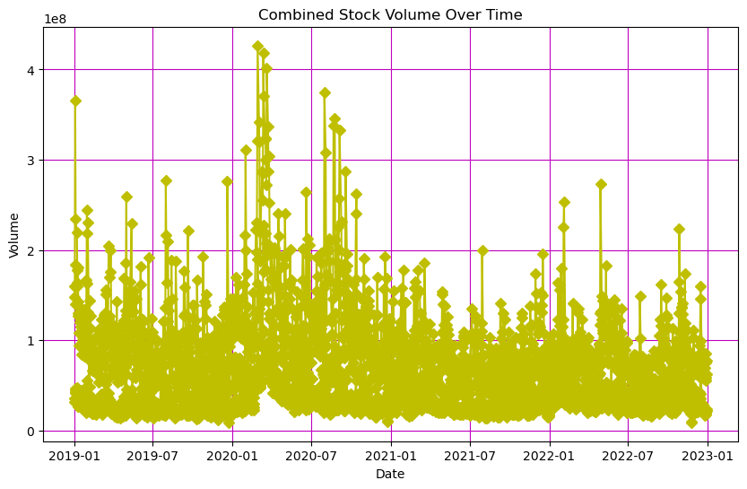

```python
import matplotlib.pyplot as plt
import pandas as pd

# Plotting
plt.figure(figsize=(10, 6))
plt.plot(combined_stock_data.index, combined_stock_data['Volume'], marker='D',linestyle='-', color='y')
plt.title('Combined Stock Volume Over Time')
plt.xlabel('Date')
plt.ylabel('Volume')
plt.grid(True, color="m")

plt.show()
```